# Geometrical Unsupervised Learning of Breast Cancer SubTyping

2024-05-09

## Abstract

[output not shown]

```r
setwd('C:/technion/Bio/project/')
library(TCGAbiolinks) # download the TCGA data

library(DESeq2)
```

```r
library(SummarizedExperiment)

library(ComplexHeatmap) # Heatmap (works with personalize distance function)
library(dendsort) # heatmap reordering columns
library(factoextra) # elbow method
library(survival) # survival analyses
library(survminer) # survival analyses
library(msigdbr) # enrichment analysis
library(clusterProfiler) # enrichment analysis
library(dplyr)
library(matrixStats)
library(circlize) # Heatmaps color
library(RColorBrewer)
library(scales)
```

## Download TCGA Data of BRCA RNA-seq

```r
query_TCGA = GDCquery(
  project = "TCGA-BRCA",
  data.category = "Transcriptome Profiling",
  experimental.strategy = "RNA-Seq",
  workflow.type = "STAR - Counts", #raw counts
  data.type = 'Gene Expression Quantification',
  sample.type = c("Primary Tumor", "Solid Tissue Normal"))#removed metastatic tumor
```

```
## o GDCquery: Searching in GDC database
```

```
## Genome of reference: hg38
```

```
## oo Accessing GDC. This might take a while...
```

```
## ooo Project: TCGA-BRCA
```

```
## oo Filtering results
```

```
## ooo By experimental.strategy
```

```
## ooo By data.type
```

```
## ooo By workflow.type
```

```
## ooo By sample.type
```

```
## oo Checking data
```

```
## ooo Checking if there are duplicated cases
```

```
## ooo Checking if there are results for the query
```

```
## o Preparing output
```

```r
GDCdownload(query = query_TCGA)
```

```
## Of the 1224 files for download 1224 already exist.
```

```
## All samples have been already downloaded
```

```r
data = GDCprepare(query_TCGA)
```

```
## |====================================================|100% Completed after 2 m
```

```
## Starting to add information to samples
```

```
##  => Add clinical information to samples
```

```
##  => Adding TCGA molecular information from marker papers
```

```
##  => Information will have prefix 'paper_'
```

```
## brca subtype information from:doi.org/10.1016/j.ccell.2018.03.014
```

```
## Available assays in SummarizedExperiment :
##   => unstranded
##   => stranded_first
##   => stranded_second
##   => tpm_unstrand
##   => fpkm_unstrand
##   => fpkm_uq_unstrand
```

## Extract metadata and Counts matrix

```r
# ---------- metadata
metadata <- as.data.frame(colData(data)[, c("gender", "vital_status", "age_at_index", "days_to_last_follow_up", "paper_pathologic_stage", "paper_BRCA_Subtype_PAM50", "tissue_type")])

colnames(metadata) <- c("Gender", "SurvivalStatus", "Age", "DaysToLastFollowUp", "PathologicStage", "PAM50", "TissueType")
metadata <- na.omit(metadata)
metadata <- metadata %>% mutate(SurvivalStatus = ifelse(SurvivalStatus == "Alive", FALSE, SurvivalStatus)) %>%
  mutate(SurvivalStatus = ifelse(SurvivalStatus == "Dead", TRUE, SurvivalStatus))
```

The metadata is biased to some Cancer sub types: Basal 176, Her2 68, LumA 529, LumB 186, Normal 35. For having a more reliable dataset we will choose an unbiased subset dataset. in total the research contains 313 samples: 35 Normal, 68 Her2 and 70 LumA, LumB and Basal.

```r
normal_data <- metadata[metadata$PAM50 == "Normal", ]
her2_data <- metadata[metadata$PAM50 == "Her2", ]
basal_data <- metadata[metadata$PAM50 == "Basal", ]
luma_data <- metadata[metadata$PAM50 == "LumA", ]
lumb_data <- metadata[metadata$PAM50 == "LumB", ]

metadata <- rbind(normal_data, her2_data, basal_data[1:70, ], luma_data[1:70, ], lumb_data[1:70, ])
```

```r
# ---------- gene names
gene_ids_to_names <- rowData(data)[, c("gene_id", "gene_name")]

# ---------- counts matrix
counts <- as.data.frame(assay(data, "unstranded"))
counts <- counts[, colnames(counts) %in% rownames(metadata)] #filter
counts <- counts[, rownames(metadata)] # reorder

# Make sure the counts matrix corresponds to the metadata
all(rownames(metadata) == colnames(counts))
```

```
## [1] TRUE
```

## Prepare and Run DESeq2

- Constructs a DESeq2 object

```r
# Set Factors for dds analyses
metadata$PathologicStage <- as.factor(metadata$PathologicStage)
metadata$SurvivalStatus <- as.factor(metadata$SurvivalStatus)

dds <- DESeqDataSetFromMatrix(countData=counts,
                              colData=metadata,
                              design= ~ PathologicStage + SurvivalStatus)
dds <- DESeq(dds)
```

```
## -- replacing outliers and refitting for 11573 genes
## -- DESeq argument 'minReplicatesForReplace' = 7
## -- original counts are preserved in counts(dds)
```

## Normalize Results

```r
res <- results(dds)
significant_genes <- length(which(res$padj < 0.05)) # number if significant genes
print(paste(significant_genes, " significant genes where found."))
```

```
## [1] "432  significant genes where found."
```

```r
counts.vst <- vst(dds) # normal the data
counts.vst <- assay(counts.vst)

var_per_gene <- apply(counts.vst, 1, var)  # Calculate the variance per gene
selectedGenes <- names(var_per_gene[order(var_per_gene, decreasing = T)][1:50]) # Take the first 50 genes

counts.vst.significant <- counts.vst[selectedGenes,]  # Construct a new matrix only for the significant genes

# Make names informative names
genes_names <- gene_ids_to_names$gene_name[gene_ids_to_names$gene_id %in% selectedGenes]
rownames(counts.vst.significant) <-genes_names
colnames(counts.vst.significant) <- paste0(metadata$Gender, "_", metadata$Age, "_", metadata$PathologicStage, "_seq", seq_along(metadata$Gender))
```

## Heatmaps by Distance functions

In this section we will plot for each distance function the Heatmap graph. The data is the normalized counts results. For each plot we added annotation for the PAM50 BRCA subtypes.

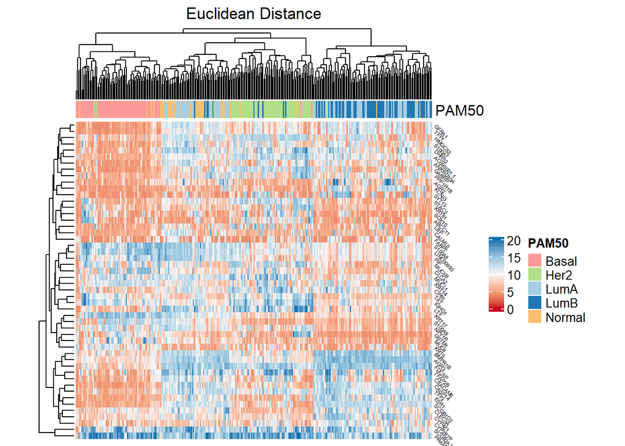

```r
# Heatmap Colors
col_fun = colorRamp2(c(0, 5, 10, 15, 20), brewer.pal(n = 5, name = "RdBu"))
col_PAM50 = c("Basal" = "#FB9A99", "Her2"="#B2DF8A", "LumA"="#A6CEE3", "LumB"="#1F78B4", "Normal"="#FDBF6F")

# ---------------------------- Heat Maps ----------------------------

# ---------------------------- Euclidean Distance

euc_dist <- dist(counts.vst.significant, method = 'euclidean') # Create euclidean distance matrix for heatmap
euc_row_dend = dendsort(hclust(dist(counts.vst.significant))) # for row ordering
euc_col_dend = dendsort(hclust(dist(t(counts.vst.significant)))) # for column ordering

# the heatmap
ht_euc = ComplexHeatmap::Heatmap(counts.vst.significant,
                      column_title = "Euclidean Distance",
                      name = " ",
                      show_row_names = TRUE, show_column_names = FALSE,
                      col = col_fun,
                      clustering_distance_rows = function(x) euc_dist, # calculates the heatmap by distance matrix
                      clustering_distance_columns = function(x) euc_dist,
                      clustering_method_rows = "complete",
                      clustering_method_columns = "complete",
                      column_dend_height = unit(2, "cm"),
                      cluster_rows = euc_row_dend, cluster_columns = euc_col_dend,
                      row_names_rot = -45,
                      row_names_gp = grid::gpar(fontsize = 4),
                      top_annotation = ComplexHeatmap::HeatmapAnnotation(PAM50 = c(metadata$PAM50), col=list(PAM50 = col_PAM50)),
                      heatmap_width = unit(12, "cm")
                      )

# ---------------------------- Pair wise Correlation

# A function that calculates pairwise distance for matrix
cor_distance <- function(mat) {
  as.dist(1 - cor(t(mat)))
}

cor_row_dend = dendsort(hclust(cor_distance(counts.vst.significant))) # for row ordering
cor_col_dend = dendsort(hclust(cor_distance(t(counts.vst.significant))))  # for column ordering

# the heatmap
ht_cor = ComplexHeatmap::Heatmap(counts.vst.significant,
                      column_title = "Correlation Pairwise Distance",
                      name = " ",
                      show_row_names = TRUE, show_column_names = FALSE,
                      col = col_fun,
                      clustering_distance_rows = function(x, y) 1 - cor(x, y), # calculates the heatmap by function for each sample
                      clustering_distance_columns = function(x, y ) 1 - cor(x, y),
                      clustering_method_rows = "complete",
                      clustering_method_columns = "complete",
                      column_dend_height = unit(2, "cm"),
                      cluster_rows = cor_row_dend, cluster_columns = cor_col_dend,
                      row_names_rot = -45,
                      row_names_gp = grid::gpar(fontsize = 4),
                      top_annotation = ComplexHeatmap::HeatmapAnnotation(PAM50 = c(metadata$PAM50), col=list(PAM50 = col_PAM50)),
                      heatmap_width = unit(12, "cm")
                      )

# ---------------------------- Cosine Similarity
library(lsa) # for cosine similarity function
# Convert similarity to distance so it can be used to create the clustering
 cos_dist <- as.dist(1 - cosine(counts.vst.significant))

# the heatmap
ht_cos = ComplexHeatmap::Heatmap(counts.vst.significant,
                      column_title = "Cosine Simalarity",
                      name = " ",
                      show_row_names = TRUE, show_column_names = FALSE,
                      col = col_fun,
                      clustering_distance_rows = function(x,y) 1- cosine(x, y), # calculates the heatmap by function for each sample
                      clustering_distance_columns = function(x,y) 1- cosine(x, y),
                      clustering_method_rows = "complete",
                      clustering_method_columns = "complete",
                      column_dend_height = unit(2, "cm"),
                      row_names_rot = -45,
                      row_names_gp = grid::gpar(fontsize = 4),
                      top_annotation = ComplexHeatmap::HeatmapAnnotation(PAM50 = c(metadata$PAM50), col=list(PAM50 = col_PAM50)),
                      heatmap_width = unit(12, "cm")
                      )


# ---------------------------- Kernel Similarity
# A function that calculates kernel similarity for matrix
ker_dis_matrix <- function(mat) {
    product_matrix <- t(mat) %*% mat
    result_matrix <- (product_matrix + 1)^2
    return(result_matrix)
}

ker_row_dend = dendsort(hclust(cos_dist)) # for row ordering
ker_col_dend = dendsort(hclust(t(cos_dist)))  # for column ordering

# the heatmap
ht_ker = ComplexHeatmap::Heatmap(counts.vst.significant,
                      column_title = "Kernel based distance (for nonlinear distance)",
                      name = " ",
                      show_row_names = TRUE, show_column_names = FALSE,
                      col = col_fun,
                      clustering_distance_rows = function(x, y) (t(x)%*%y + 1)^2, # calculates the heatmap by function for each sample
                      clustering_distance_columns = function(x, y) (t(x)%*%y + 1)^2,
                      clustering_method_rows = "complete",
                      clustering_method_columns = "complete",
                      column_dend_height = unit(2, "cm"),
                      row_names_rot = -45,
                      row_names_gp = grid::gpar(fontsize = 4),
                      top_annotation = ComplexHeatmap::HeatmapAnnotation(PAM50 = c(metadata$PAM50), col=list(PAM50 = col_PAM50)),
                      heatmap_width = unit(12, "cm")
                      )


# ---------------------------- Mahalanobis Distance

rescaled_data <- rescale(counts.vst.significant) # normalize for smaller values for the mahalanobis distance function, so it wont exceed the max int value of the computer

# data for the mahalanobis_distance function
means <- colMeans(rescaled_data)
cov_matrix <- cov(rescaled_data) + diag(1e-4, ncol(rescaled_data)) # add a very small number so the matrix will be diagonalizable
n_features <- ncol(rescaled_data)

# A function that calculates mahalanobis distance for samples
mahalanobis_distance <- function(x, y) {
  x <- matrix(x, nrow = 1, ncol = n_features)
  y <- matrix(y, nrow = 1, ncol = n_features)

  # Check if x or y need padding
  if (length(x) < n_features) {
    x <- x + rep(0, n_features - length(x))
  }
  if (length(y) < n_features) {
    y <- y + rep(0, n_features - length(y))
  }
  # Calculate distance
  return(as.numeric(sqrt((x - y)%*% solve(cov_matrix) %*% t(x - y))))
}

# the heatmap
ht_mah = ComplexHeatmap::Heatmap(counts.vst.significant,
                      column_title = "Mahalanobis distance",
                      name = " ",
                      show_row_names = TRUE, show_column_names = FALSE,
                      col = col_fun,
                      clustering_distance_rows = function(x,y) mahalanobis_distance(x,y), # calculates the heatmap by function for each sample
                      clustering_distance_columns = function(x,y) mahalanobis_distance(x,y),
                      clustering_method_rows = "complete",
                      clustering_method_columns = "complete",
                      column_dend_height = unit(2, "cm"),
                      row_names_rot = -45,
                      row_names_gp = grid::gpar(fontsize = 4),
                      top_annotation = ComplexHeatmap::HeatmapAnnotation(PAM50 = c(metadata$PAM50), col=list(PAM50 = col_PAM50)),
                      heatmap_width = unit(12, "cm")
                      )

# ---------------------------- PCA

pcaResults = prcomp(t(counts.vst.significant))
pca_hc = ComplexHeatmap::Heatmap(counts.vst.significant,
                      column_title = "distance by PCA",
                      name = " ",
                      show_row_names = TRUE, show_column_names = FALSE,
                      col = col_fun,
                      clustering_distance_rows = function(x, y) sqrt(sum((pcaResults$x[x, ] -   pcaResults$x[y, ])^2)), # calculates the heatmap by function for each sample
                      clustering_distance_columns = function(x, y) sqrt(sum((pcaResults$x[x, ] - pcaResults$x[y, ])^2)),
                      clustering_method_rows = "complete",
                      clustering_method_columns = "complete",
                      column_dend_height = unit(2, "cm"),
                      row_names_rot = -45,
                      row_names_gp = grid::gpar(fontsize = 4),
                      top_annotation = ComplexHeatmap::HeatmapAnnotation(PAM50 = c(metadata$PAM50), col=list(PAM50 = col_PAM50)),
                      heatmap_width = unit(12, "cm")
                      )


# prints the plots
ht_euc
```

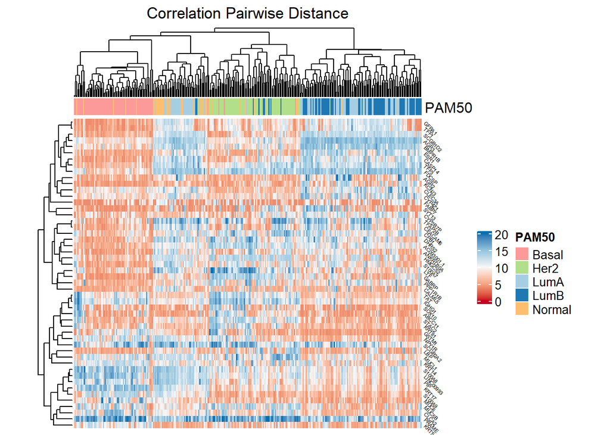

```r
ht_cor
```

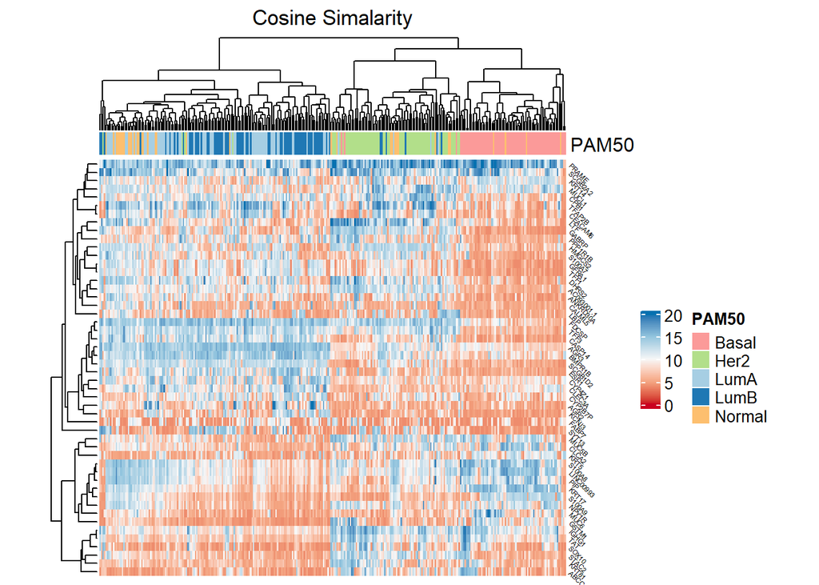

```r
ht_cos
```

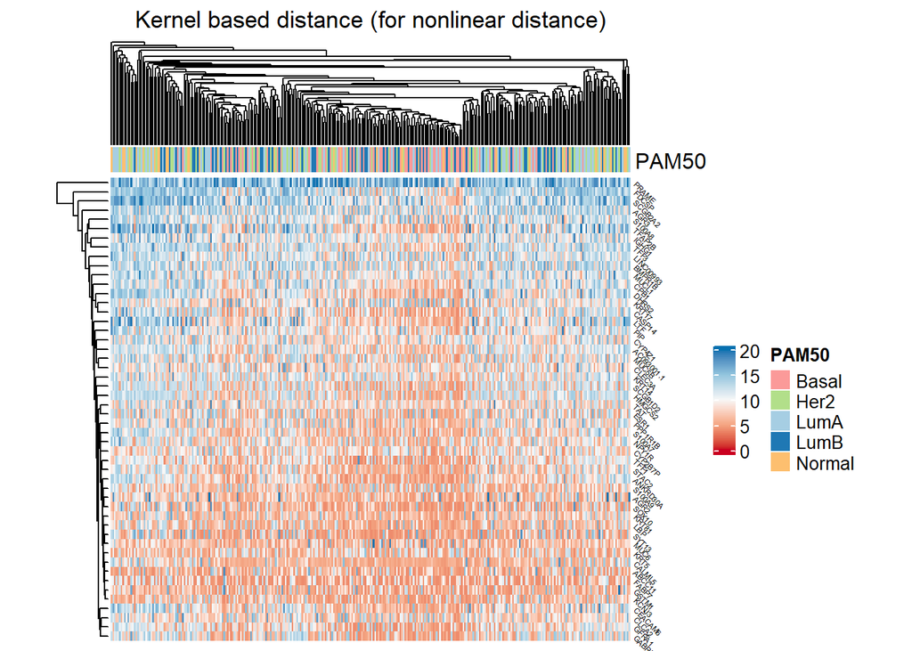

```r
ht_ker
```

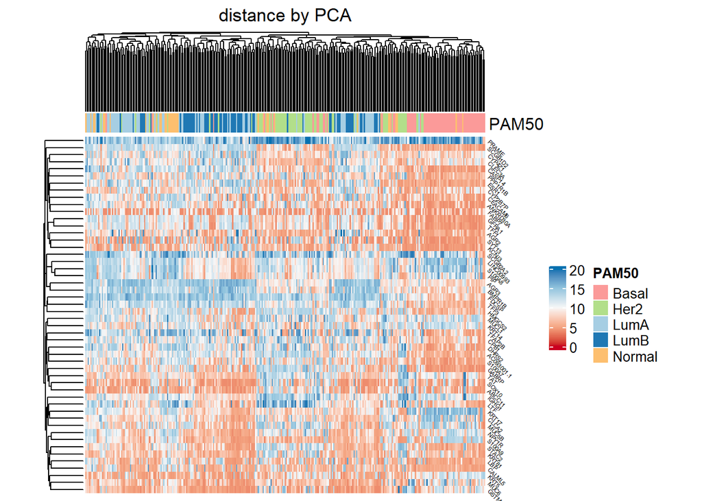

```r
pca_hc
```

## Clustring by Distance functions

In this section we will see the hierarchical clustering plot and add the clustering results for the metadata. Note that for the Kernel distance, function clustering where not created. So further analyses for this distance functions were not calculated.

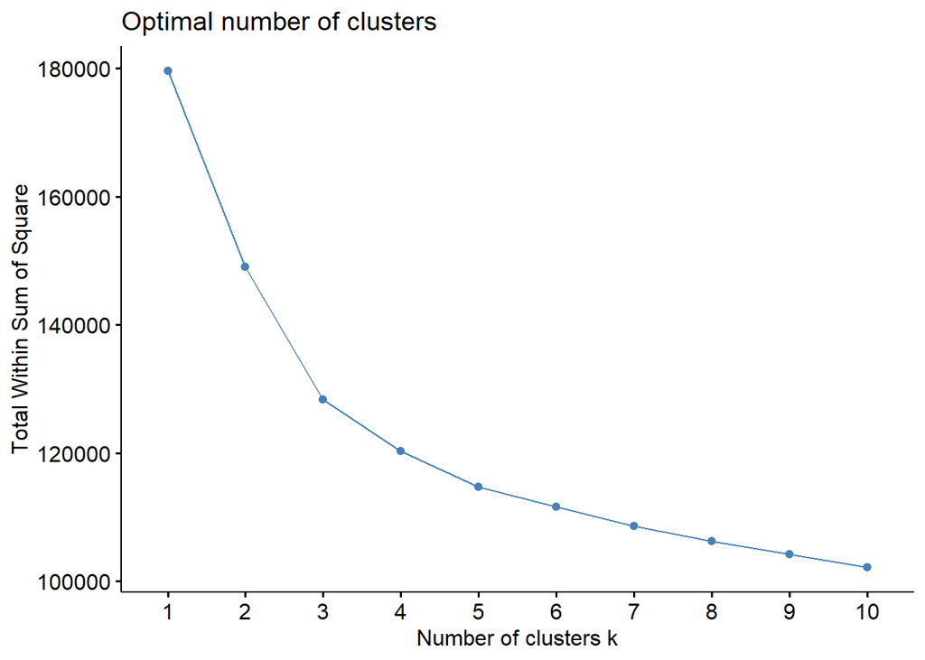

```r
# Elbow Graph by Generic Clustering
fviz_nbclust(t(counts.vst.significant), FUN = hcut, method = "wss")
```

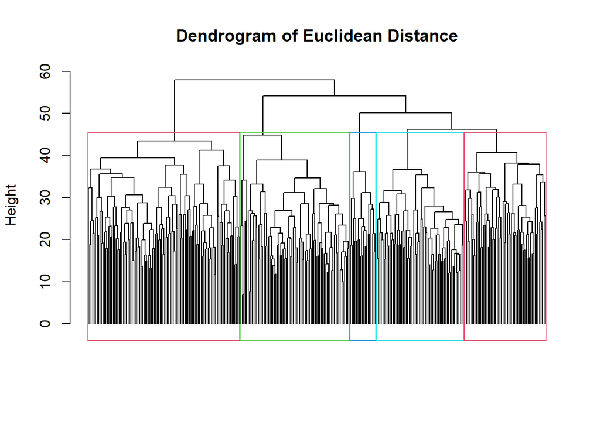

```r
k <- 5

# Clustering By distance functions and add to metadata

# ---------------------------- Euclidean Distance
hclust_res_euc <- hclust(dist(t(counts.vst.significant))) # clustering
plot(hclust_res_euc, cex = 0.6, hang = -1, main = "Dendrogram of Euclidean Distance", labels=FALSE, xlab="", sub="") # plot
rect.hclust(hclust_res_euc, k = k, border = 2:5)
```

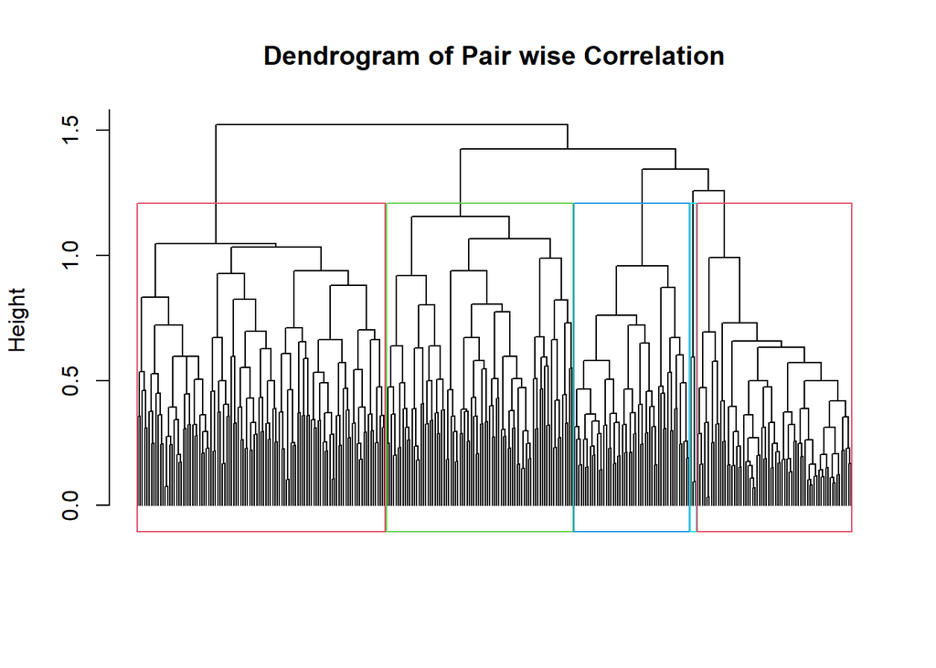

```r
clusters_euc <- cutree(hclust_res_euc, k =k) # add to metadata
metadata$ClusterEuc <- clusters_euc

# ---------------------------- Pair wise Correlation
hclust_res_cor <- hclust(cor_distance(t(counts.vst.significant))) # clustering
plot(hclust_res_cor, cex = 0.6, hang = -1, main = "Dendrogram of Pair wise Correlation", labels=FALSE, xlab="", sub="") # plot
rect.hclust(hclust_res_cor, k = k, border = 2:5)
```

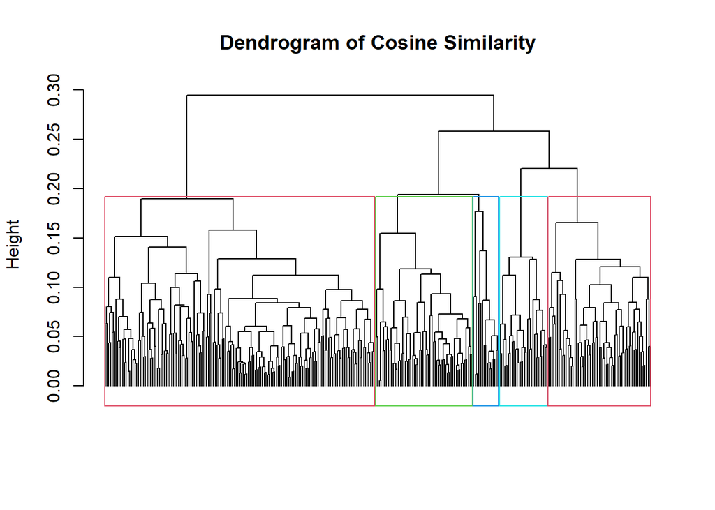

```r
clusters_cor <- cutree(hclust_res_cor, k =k) # add to metadata
metadata$ClusterCor <- clusters_cor

# ---------------------------- Cosine Similarity
hclust_res_cos <- hclust(t(cos_dist)) # clustering
plot(hclust_res_cos, cex = 0.6, hang = -1, main = "Dendrogram of Cosine Similarity", labels=FALSE, xlab="", sub="") # plot
rect.hclust(hclust_res_cos, k = k, border = 2:5)
```

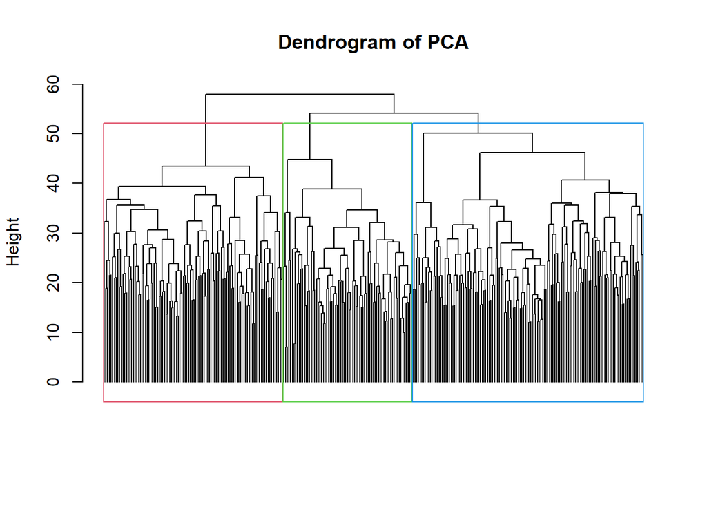

```r
clusters_cos <- cutree(hclust_res_cos, k =k) # add to metadata
metadata$ClusterCos <- clusters_cos

# ---------------------------- Kernel Similarity
#not clustering where created.

# ---------------------------- PCA
pcaResults <- prcomp(t(counts.vst.significant))
hclust_res_pca <- hclust(dist(pcaResults$x)) # clustering
plot(hclust_res_pca, cex = 0.6, hang = -1, main = "Dendrogram of PCA", labels=FALSE, xlab="", sub="") # plot
rect.hclust(hclust_res_pca, k = 3, border = 2:5)
```

```r
clusters_pca <- cutree(hclust_res_pca, k =3) # add to metadata
metadata$ClusterPCA <- clusters_pca
```

## Survival Analyses

In this section we will do survival analyses with “Kaplan-Meir” curve.

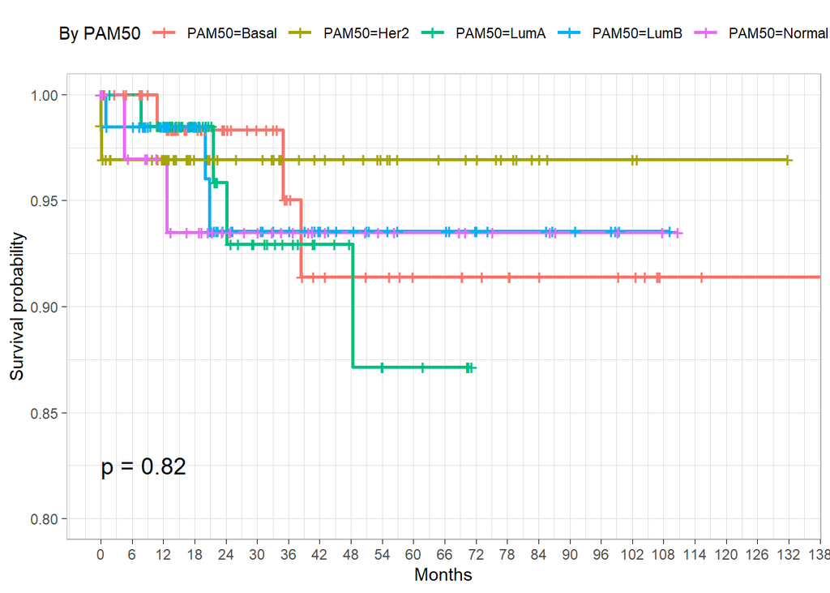

```r
metadata$SurvivalStatus <- as.logical(metadata$SurvivalStatus)
# ---------------------------- PAM50
ggsurvplot(
    survfit(Surv(metadata$DaysToLastFollowUp, metadata$SurvivalStatus) ~ PAM50, data = metadata),
    data = metadata,
    xlab = "Months",
    xscale = 30.4,
    break.x.by = 182.4,
    surv.median.line = "hv",
    legend.title = "By PAM50",
    pval = TRUE,
    pval.coord = c(0.1, 0.825),
    xlim = c(0,4000),
    ylim=c(0.8, 1),
    ggtheme = theme_light()
)
```

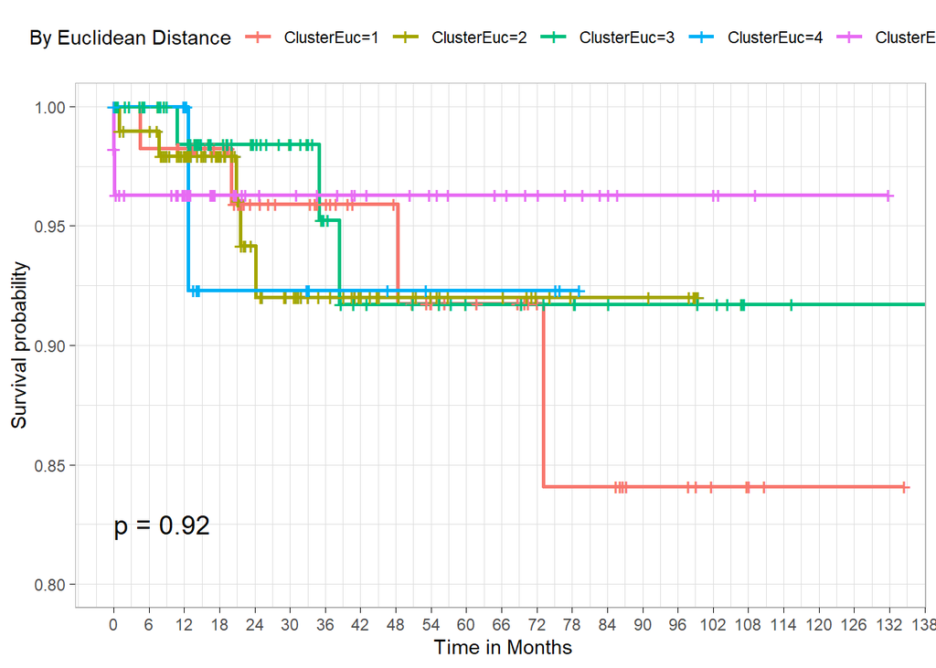

```r
# ---------------------------- Euclidean Distance
ggsurvplot(
    survfit(Surv(metadata$DaysToLastFollowUp, metadata$SurvivalStatus) ~ ClusterEuc, data = metadata),
    data = metadata,
    xlab = " Time in Months",
    xscale = 30.4,
    xlim = c(0,4000),
    ylim=c(0.8, 1),
    break.x.by = 182.4,
    pval = TRUE,
    pval.coord = c(0.1, 0.825),
    surv.median.line = "hv",
    legend.title = "By Euclidean Distance",
    ggtheme = theme_light()
)
```

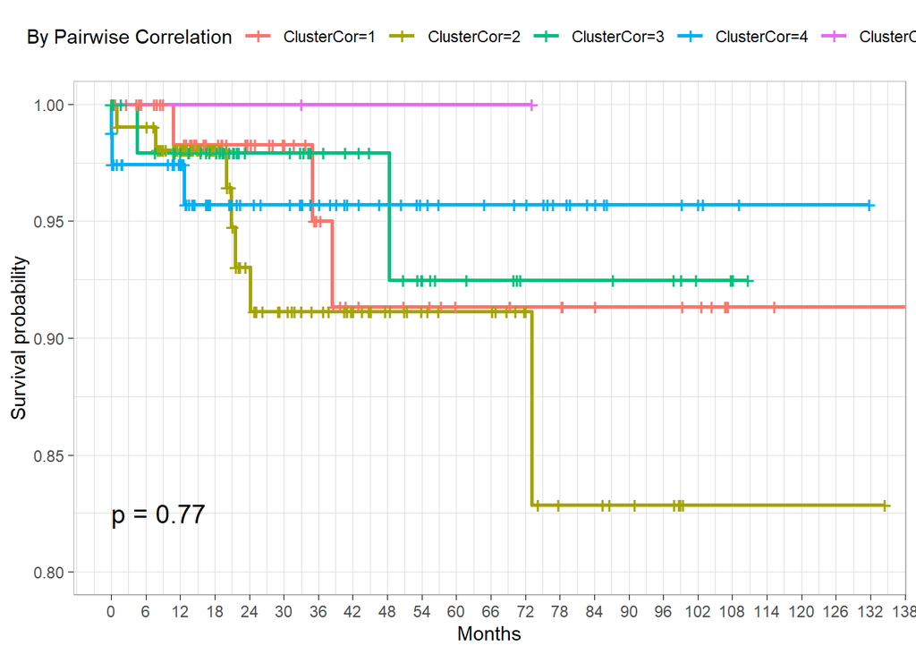

```r
# ---------------------------- Pairwise Correlation
ggsurvplot(
    survfit(Surv(metadata$DaysToLastFollowUp, metadata$SurvivalStatus) ~ ClusterCor, data = metadata),
    data = metadata,
    xlab = "Months",
    xscale = 30.4,
    break.x.by = 182.4,
    surv.median.line = "hv",
    legend.title = "By Pairwise Correlation",
    xlim = c(0,4000),
    ylim=c(0.8, 1),
    pval = TRUE,
    pval.coord = c(0.1, 0.825),
    ggtheme = theme_light()
)
```

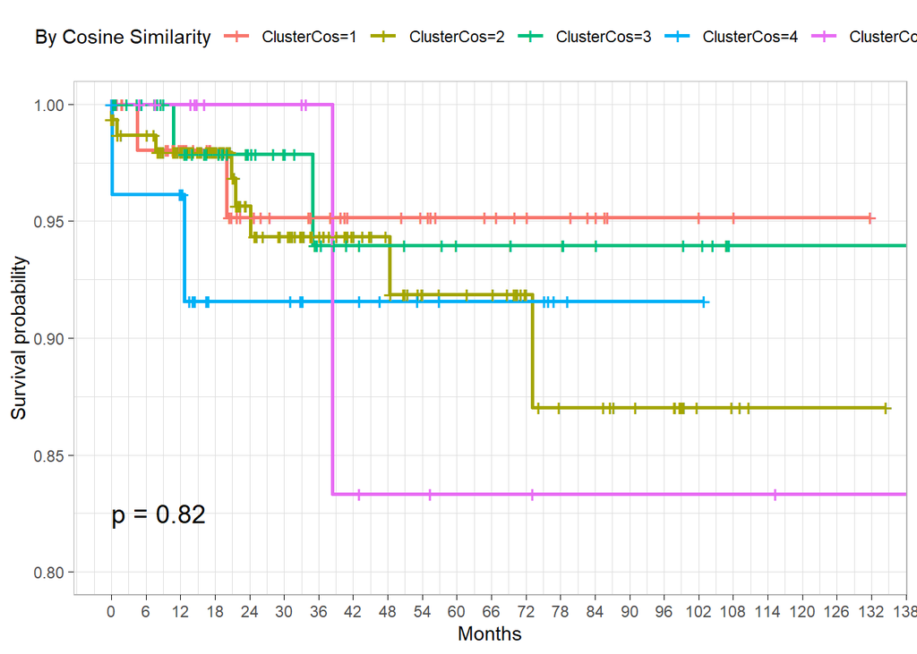

```r
# ----------------------------  Cosine Similarity
ggsurvplot(
    survfit(Surv(metadata$DaysToLastFollowUp, metadata$SurvivalStatus) ~ ClusterCos, data = metadata),
    data = metadata,
    xlab = "Months",
    xscale = 30.4,
    break.x.by = 182.4,
    surv.median.line = "hv",
    legend.title = "By Cosine Similarity",
    xlim = c(0,4000),
    ylim=c(0.8, 1),
    pval = TRUE,
    pval.coord = c(0.1, 0.825),
    ggtheme = theme_light()
)
```

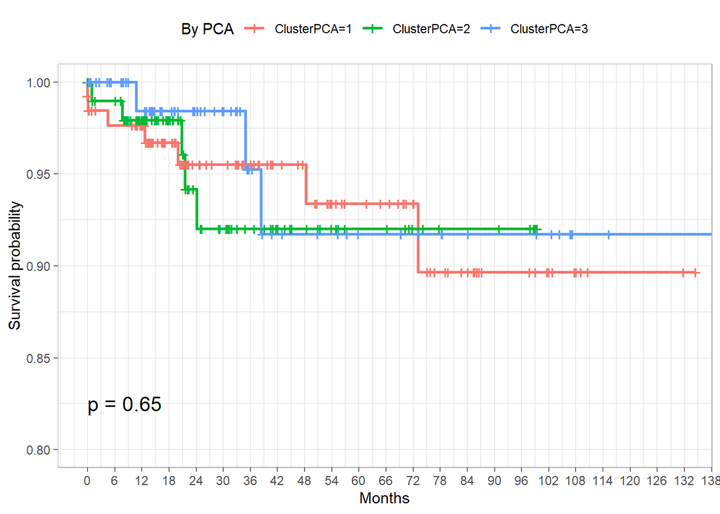

```r
# ---------------------------- PCA
ggsurvplot(
    survfit(Surv(metadata$DaysToLastFollowUp, metadata$SurvivalStatus) ~ ClusterPCA, data = metadata),
    data = metadata,
    xlab = "Months",
    xscale = 30.4,
    break.x.by = 182.4,
    surv.median.line = "hv",
    legend.title = "By PCA",
    xlim = c(0,4000),
    ylim=c(0.8, 1),
    pval = TRUE,
    pval.coord = c(0.1, 0.825),
    ggtheme = theme_light()
)
```

## Enrichment Analysis

This section is divided to 2 parts. The first part is GSEA on the counts.vst results, where the results are analyses by cluster. In this section no significant pathways for any cluster of the distance functions. Because of the similarity between the results, we only presents the euclidean distance and the PCA.

```r
# prepare hallmarks
hallmarks <- msigdbr(species = "Homo sapiens", category = "H") %>%
  dplyr::select(gs_name, gene_symbol)
hallmarks <- msigdbr(species = "Homo sapiens", category = "H")
hallmarks <- hallmarks[,c('gs_name', 'gene_symbol')]

# ---------------------------- Euclidean Distance

results_list <- list()
for (i in unique(metadata$ClusterEuc)) {
  cluster_samples <- which(metadata$ClusterEuc == i)
  gene_list <- apply(counts.vst.significant[, cluster_samples], 1, var)
  names(gene_list) <- rownames(counts.vst.significant)
  gene_list <- sort(gene_list, decreasing = TRUE)

  gsea_results <- GSEA(gene_list, TERM2GENE = hallmarks, verbose = TRUE, scoreType = "pos")
  results_list[[paste("Cluster", i)]] <- gsea_results
}
```

```
## preparing geneSet collections...
```

```
## GSEA analysis...
```

```
## no term enriched under specific pvalueCutoff...
```

```
## preparing geneSet collections...
```

```
## GSEA analysis...
```

```
## no term enriched under specific pvalueCutoff...
```

```
## preparing geneSet collections...
```

```
## GSEA analysis...
```

```
## no term enriched under specific pvalueCutoff...
```

```
## preparing geneSet collections...
```

```
## GSEA analysis...
```

```
## no term enriched under specific pvalueCutoff...
```

```
## preparing geneSet collections...
```

```
## GSEA analysis...
```

```
## no term enriched under specific pvalueCutoff...
```

```r
# Assuming the GSEA results are stored in 'results_list'
for (i in names(results_list)) {
  gsea_results <- results_list[[i]]

  # Check if the results are empty
  if (length(gsea_results) == 0 || nrow(gsea_results@result) == 0) {
    print(paste("No significant pathways for Euclidean", i))
  } else {
    print(paste("Results for", i))
    dotplot(gsea_results)
  }
}
```

```
## [1] "No significant pathways for Euclidean Cluster 1"
## [1] "No significant pathways for Euclidean Cluster 2"
## [1] "No significant pathways for Euclidean Cluster 3"
## [1] "No significant pathways for Euclidean Cluster 4"
## [1] "No significant pathways for Euclidean Cluster 5"
```

```r
# ----------------------------  PCA

results_list <- list()
for (i in unique(metadata$ClusterPCA)) {
  cluster_samples <- which(metadata$ClusterPCA == i)
  gene_list <- apply(counts.vst.significant[, cluster_samples], 1, var)
  names(gene_list) <- rownames(counts.vst.significant)
  gene_list <- sort(gene_list, decreasing = TRUE)

  gsea_results <- GSEA(gene_list, TERM2GENE = hallmarks, verbose = TRUE, scoreType = "pos")
  results_list[[paste("Cluster", i)]] <- gsea_results
}
```

```
## preparing geneSet collections...
```

```
## GSEA analysis...
```

```
## no term enriched under specific pvalueCutoff...
```

```
## preparing geneSet collections...
```

```
## GSEA analysis...
```

```
## no term enriched under specific pvalueCutoff...
```

```
## preparing geneSet collections...
```

```
## GSEA analysis...
```

```
## no term enriched under specific pvalueCutoff...
```

```r
# Assuming the GSEA results are stored in 'results_list'
for (i in names(results_list)) {
  gsea_results <- results_list[[i]]

  # Check if the results are empty
  if (length(gsea_results) == 0 || nrow(gsea_results@result) == 0) {
    print(paste("No significant pathways for PCA Cluster", i))
  } else {
    print(paste("Results for", i))
    dotplot(gsea_results)
  }
}
```

```
## [1] "No significant pathways for PCA Cluster Cluster 1"
## [1] "No significant pathways for PCA Cluster Cluster 2"
## [1] "No significant pathways for PCA Cluster Cluster 3"
```

The second part we repeated the DESeq analyses design by each distance function Clustering and did the GSEA by the new dds results.

```r
# ---------------------------- Euclidean Distance

metadata$ClusterEuc <- as.factor(metadata$ClusterEuc)
euclidean_dds <- DESeqDataSetFromMatrix(countData=counts,
                              colData=metadata,
                              design= ~ ClusterEuc)

euclidean_dds <- DESeq(euclidean_dds)
```

```
## -- replacing outliers and refitting for 9868 genes
## -- DESeq argument 'minReplicatesForReplace' = 7
## -- original counts are preserved in counts(dds)
```

```r
euc.counts.vst <- vst(euclidean_dds)
euc.counts.vst <- assay(euc.counts.vst)

rownames(euc.counts.vst) <- gene_ids_to_names$gene_name[gene_ids_to_names$gene_id %in% rownames(euc.counts.vst)]
var_per_gene <- apply(euc.counts.vst, 1, var)  # Calculate the variance per gene
var_per_gene <- var_per_gene[order(var_per_gene, decreasing = T)]
selectedGenes <- names(var_per_gene[order(var_per_gene, decreasing = T)])
selectedGenes <- gene_ids_to_names$gene_name[gene_ids_to_names$gene_id %in% selectedGenes]

hm <- GSEA(var_per_gene, TERM2GENE = hallmarks, pvalueCutoff = 0.05, eps = 0)
```

```
## preparing geneSet collections...
```

```
## GSEA analysis...
```

```
## leading edge analysis...
```

```
## done...
```

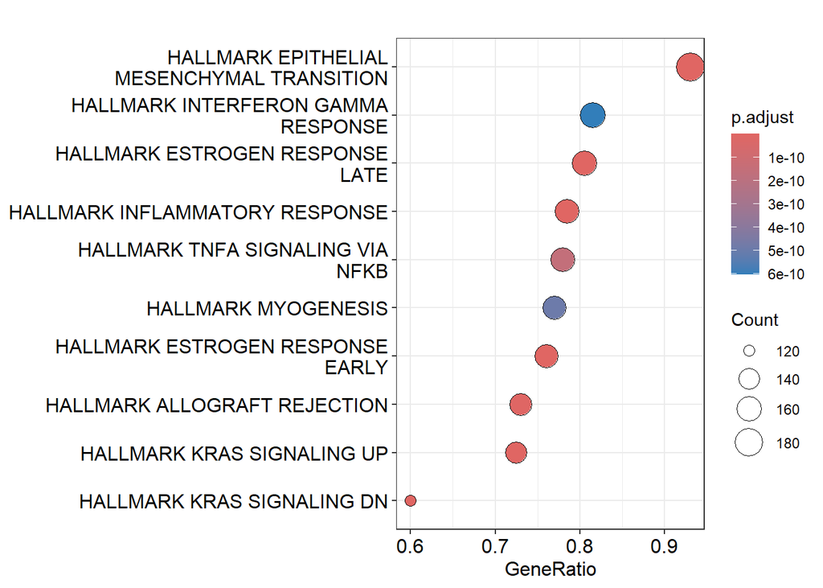

```r
dotplot(hm)
```

```r
# ---------------------------- Pairwise Correlation
metadata$ClusterCor <- as.factor(metadata$ClusterCor)
correlation_dds <- DESeqDataSetFromMatrix(countData=counts,
                              colData=metadata,
                              design= ~ ClusterCor)
correlation_dds <- DESeq(correlation_dds)
```

```
## -- replacing outliers and refitting for 4864 genes
## -- DESeq argument 'minReplicatesForReplace' = 7
## -- original counts are preserved in counts(dds)
```

```r
cor.counts.vst <- vst(correlation_dds)
cor.counts.vst <- assay(cor.counts.vst)

rownames(cor.counts.vst) <- gene_ids_to_names$gene_name[gene_ids_to_names$gene_id %in% rownames(cor.counts.vst)]
var_per_gene <- apply(cor.counts.vst, 1, var)  # Calculate the variance per gene
var_per_gene <- var_per_gene[order(var_per_gene, decreasing = T)]
selectedGenes <- names(var_per_gene[order(var_per_gene, decreasing = T)])
selectedGenes <- gene_ids_to_names$gene_name[gene_ids_to_names$gene_id %in% selectedGenes]

hallmarks <- msigdbr(species = "Homo sapiens", category = "H")
hallmarks <- hallmarks[,c('gs_name', 'gene_symbol')]
hm <- GSEA(var_per_gene, TERM2GENE = hallmarks, pvalueCutoff = 0.05, eps = 0)
```

```
## preparing geneSet collections...
```

```
## GSEA analysis...
```

```
## leading edge analysis...
```

```
## done...
```

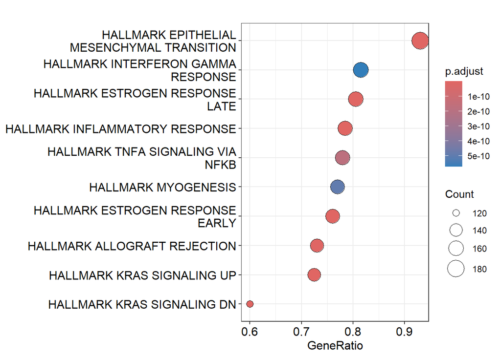

```r
dotplot(hm)
```

```r
# ----------------------------  Cosine Similarity
metadata$ClusterCos <- as.factor(metadata$ClusterCos)
cosine_dds <- DESeqDataSetFromMatrix(countData=counts,
                              colData=metadata,
                              design= ~ ClusterCos)
cosine_dds <- DESeq(cosine_dds)
```

```
## -- replacing outliers and refitting for 9778 genes
## -- DESeq argument 'minReplicatesForReplace' = 7
## -- original counts are preserved in counts(dds)
```

```r
cos.counts.vst <- vst(cosine_dds)
cos.counts.vst <- assay(cos.counts.vst)

rownames(cos.counts.vst) <- gene_ids_to_names$gene_name[gene_ids_to_names$gene_id %in% rownames(cos.counts.vst)]
var_per_gene <- apply(cos.counts.vst, 1, var)  # Calculate the variance per gene
var_per_gene <- var_per_gene[order(var_per_gene, decreasing = T)]
selectedGenes <- names(var_per_gene[order(var_per_gene, decreasing = T)])
selectedGenes <- gene_ids_to_names$gene_name[gene_ids_to_names$gene_id %in% selectedGenes]

hallmarks <- msigdbr(species = "Homo sapiens", category = "H")
hallmarks <- hallmarks[,c('gs_name', 'gene_symbol')]
hm <- GSEA(var_per_gene, TERM2GENE = hallmarks, pvalueCutoff = 0.05, eps = 0)
```

```
## preparing geneSet collections...
```

```
## GSEA analysis...
```

```
## leading edge analysis...
```

```
## done...
```

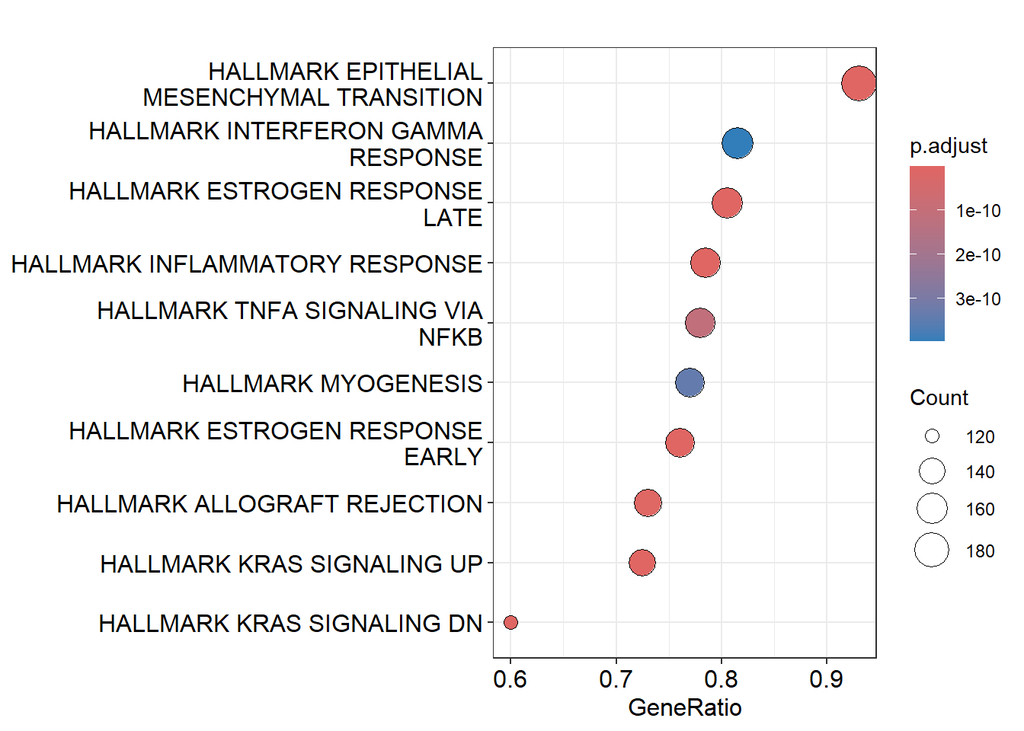

```r
dotplot(hm)
```

```r
# ----------------------------  PCA
metadata$ClusterPCA <- as.factor(metadata$ClusterPCA)
pca_dds <- DESeqDataSetFromMatrix(countData=counts,
                              colData=metadata,
                              design= ~ ClusterPCA)
pca_dds <- DESeq(pca_dds)
```

```
## -- replacing outliers and refitting for 12224 genes
## -- DESeq argument 'minReplicatesForReplace' = 7
## -- original counts are preserved in counts(dds)
```

```r
pca.counts.vst <- vst(pca_dds)
pca.counts.vst <- assay(pca.counts.vst)

rownames(pca.counts.vst) <- gene_ids_to_names$gene_name[gene_ids_to_names$gene_id %in% rownames(pca.counts.vst)]
var_per_gene <- apply(pca.counts.vst, 1, var)  # Calculate the variance per gene
var_per_gene <- var_per_gene[order(var_per_gene, decreasing = T)]
selectedGenes <- names(var_per_gene[order(var_per_gene, decreasing = T)])
selectedGenes <- gene_ids_to_names$gene_name[gene_ids_to_names$gene_id %in% selectedGenes]

hallmarks <- msigdbr(species = "Homo sapiens", category = "H")
hallmarks <- hallmarks[,c('gs_name', 'gene_symbol')]
hm <- GSEA(var_per_gene, TERM2GENE = hallmarks, pvalueCutoff = 0.05, eps = 0)
```

```
## preparing geneSet collections...
```

```
## GSEA analysis...
```

```
## leading edge analysis...
```

```
## done...
```

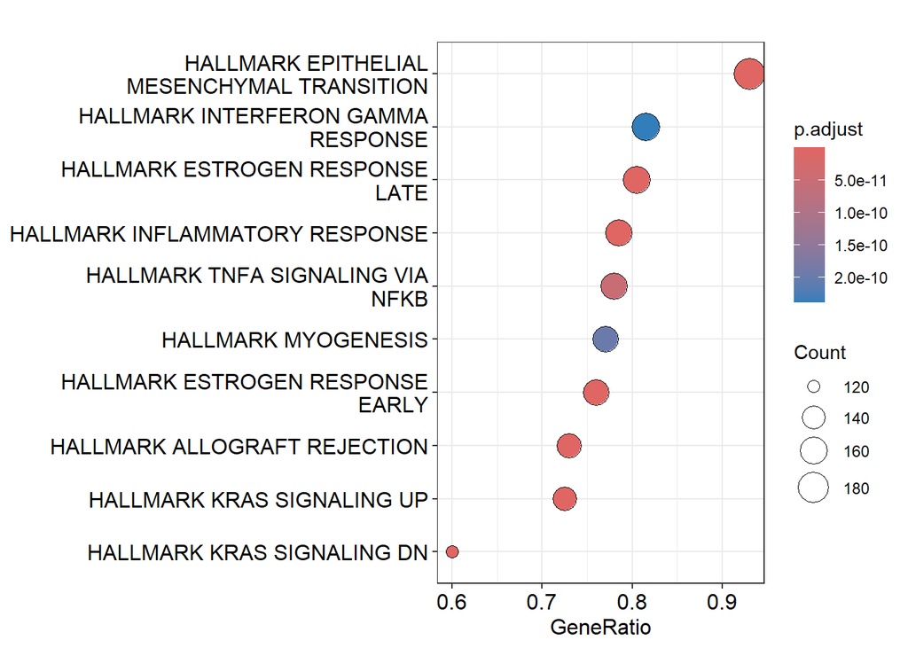

```r
dotplot(hm)
```

[output not shown]